# Sampling, modeling, experiments that might get at age-0 and age-1 survival- N-Mixture models Part 1

Michael E. Colvin

17 July 2016

## Overview

The Pradel model might be a way to model the effect of habitat modification like IRC construction and recruitment, assuming recruitment is postitively related to IRC habitat. The time frame on this type of analysis might be a bit long as it takes Pallid Sturgeon a while to recruit to the population. Also the effect of IRC, or altnernative management actions, is realized as the reach, segment, or basin level depending on how the design is set up. Understanding how Pallid Sturgeon are responding to individual IRCs is also imporant to evaluate IRC effectiveness. Therefore sampling within an IRC makes sense to evaluate whether it is effective and whether effeciveness varies among IRCs.

Traditionally metrics like catch per unit effort (CPUE) would be used for comparisons (i.e., is cpue higher in one IRC relative to another). Comparing CPUE requires many assumptions as it relates to catchability ($q$), where Catch is $C = q\cdot f \cdot abundance$. Recent advances in N-mixture models relaxes this assumption by estimating capture probability for each site. One thing to note is that capture probability and catchability are not the same thing. Caveats aside the N-mixture provides a method to estimate density, accounting for imperfect capture. The gist of the approach is to repeatedly sample a site. The number of fish captured is a function of the underlying density and capture probability. For example if there were 100 fish at a site and your gear had a capture probability of 0.8 and then you sampled that site 5 times, you would expect to capture approximately 80 fish each time. In reality the data might look like this: 81 74 85 82 70,this is essentially a capture history but with counts instead of 0s and 1s. Because there was temporal replicates one can estimated a capature probability.

As it relates to IRC habitat, the model may give the ability to estimate the density of hard to capture Pallid Sturgeon and the ability to compare among IRC habitats. The design is not that different from what would occur for typical fishery surveys, sample sites are randomly selected within an IRC habitat and then repeated sampling is conducted to get the count history.

## Application to IRC monitoring

### What a hypothetical IRC might look like

Suppose there is an IRC habitat with a spatial domain that looks like the image below. The blue represents depth (darker = deeper).

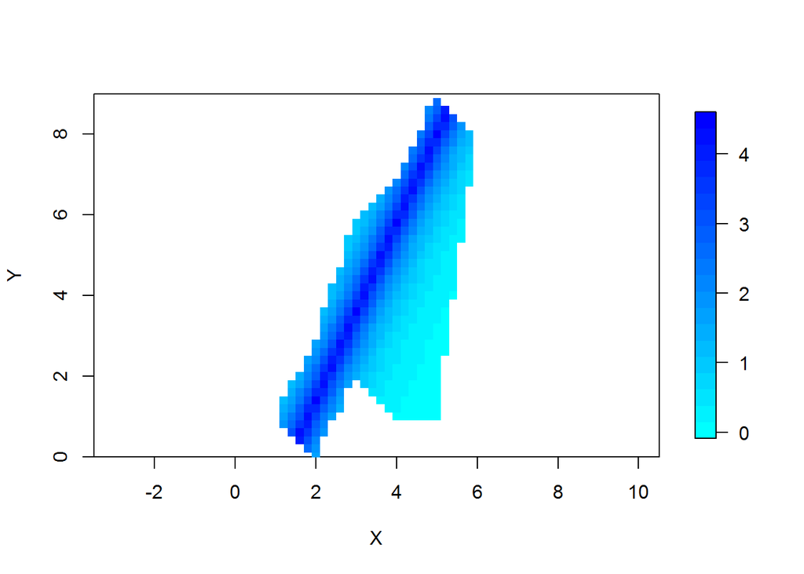

Within the polygon above the true density of Pallid Sturgeon is 4 fish per square meter (i.e., $\lambda = 4$ in *N*-mixture jargon). Applying that density to the polygon, the density of fish looks like this:

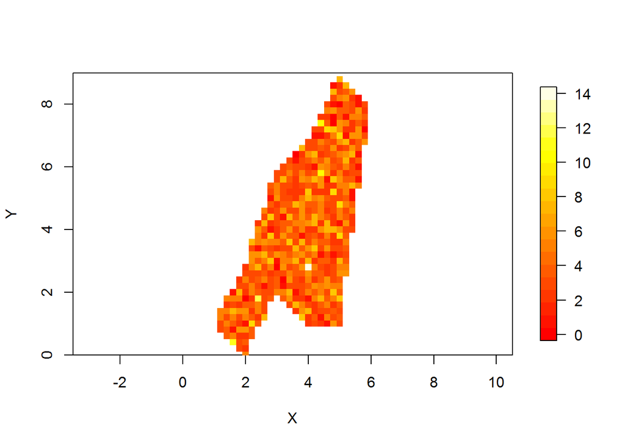

Using the framework, a survey can sample sites within the IRC habitat. Suppose 20 sites are used. That would look like the image below.

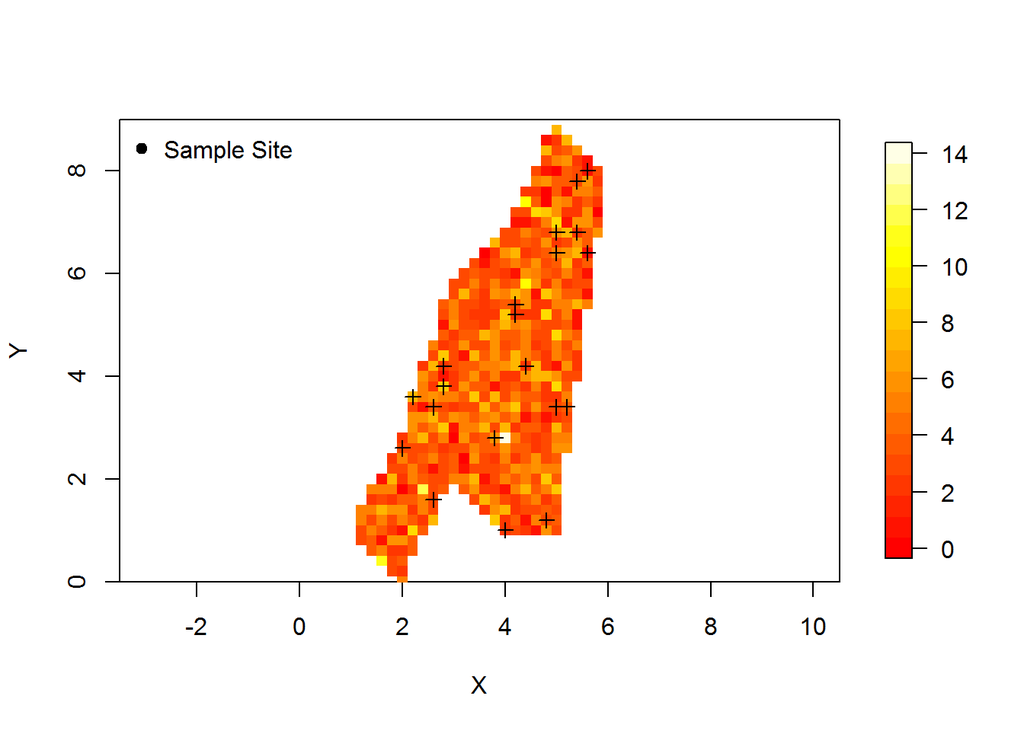

## Estimating abundance

Using the 20 samples abundance can be estimated using an *N*-mixture model, given some assumptions. Variables estimated by the *N*-mixture model are:

- $\lambda$ is initial population density
- $p$ is capture probability

### No covariates: $\lambda$ and $p$ constant

The sampling design in the plot above illustrates how the design might play out in an IRC habitat. Each site would be visted 2 or more times either within a day or within a time period that is sufficiently short, such that demographic closure can be assumed. The process assumes temporal replicates, however spatial replicates have been used with occupancy models, so it is suggestive that it might work for *N*-mixture models. This first analysis assumes there is no uderlying relationship with abiotic or biotic covariates such as depth on abundance or capture probability, i.e., density arises from a Poisson process.

The code below generates catches at 20 sites over 5 occasions given the abundance at the site and a capture probability ($p$) = 0.4.

```r
# GENERATE CAPTURE HISTORIES
nocc<-5
p<-0.4
cap_dat<- matrix(0,nsamples,nocc)
for(i in 1:nsamples)
    {
    cap_dat[i,]<- rbinom(nocc,sampleSites$abundance[i],p)
    }
```

The simulated catch at each of the 20 sites for 5 occasions is shown below.

| siteId | occasion.1 | occasion.2 | occasion.3 | occasion.4 | occasion.5 |
| --- | --- | --- | --- | --- | --- |
| 1 | 1 | 1 | 1 | 0 | 3 |
| 2 | 1 | 1 | 0 | 1 | 0 |
| 3 | 3 | 0 | 1 | 1 | 1 |
| 4 | 1 | 0 | 2 | 1 | 2 |
| 5 | 4 | 5 | 2 | 2 | 3 |
| 6 | 0 | 0 | 0 | 0 | 1 |
| 7 | 0 | 1 | 1 | 0 | 0 |
| 8 | 2 | 4 | 2 | 1 | 3 |
| 9 | 0 | 4 | 2 | 2 | 1 |
| 10 | 1 | 1 | 0 | 2 | 1 |
| 11 | 1 | 1 | 0 | 0 | 0 |
| 12 | 2 | 2 | 1 | 2 | 0 |
| 13 | 4 | 1 | 2 | 0 | 1 |
| 14 | 0 | 1 | 2 | 1 | 1 |
| 15 | 1 | 1 | 0 | 0 | 1 |
| 16 | 0 | 0 | 0 | 1 | 1 |
| 17 | 3 | 2 | 4 | 2 | 4 |
| 18 | 4 | 1 | 0 | 2 | 3 |
| 19 | 1 | 0 | 1 | 1 | 0 |
| 20 | 0 | 1 | 2 | 1 | 0 |

The data in the table above is then used to estimate $\lambda$ and $p$ using the *N*-mixture model. This is done using the `pcount()` function from the `unmarked` library. Note there was some manipulition of the data using the `unmarkedFramePCount()` function to process the input data prior to fitting the model.

```r
# Prepare data
irc_data <- unmarkedFramePCount(y = cap_dat)
fit <- pcount(~1 ~ 1, irc_data, K=50)
summary(fit)
```

```
##
## Call:
## pcount(formula = ~1 ~ 1, data = irc_data, K = 50)
##
## Abundance (log-scale):
##  Estimate    SE    z     P(>|z|)
##      1.45 0.288 5.04 0.000000464
##
## Detection (logit-scale):
##  Estimate    SE     z P(>|z|)
##    -0.883 0.392 -2.25  0.0243
##
## AIC: 282.5302
## Number of sites: 20
## optim convergence code: 0
## optim iterations: 31
## Bootstrap iterations: 0
```

Once the model is fit and estimates are returned, the estimates are then backtransformed from log and logit scale for abundance and capture probability resepctively.

```r
exp(coef(fit)[1]) # should be close to lambda
```

```
## lam(Int)
## 4.272928
```

```r
plogis(coef(fit)[2]) # should be close p
```

```
##    p(Int)
## 0.2925394
```

After fitting the *N*-mixture model the estimate of $\lambda$ was 4.27, recall that the value used to generate the data was 4 and the estimate of $p$ was 0.29, recall the that value used was 0.4. The estimates should be in the ballpark.

### Covariates for $\lambda$ and $p$

The no covariates for $\lambda$ and $p$ is a rather unrealistic condition in nature. This example shows how a biologically relevant metric like depth can be used to model abundance and capture probability. Note that this example assumes there is a true underlying relationship with the abundance and capture probabiliyt of Pallid Sturgeon and depth. Recall the figure above of the hypothesized IRC habitat with varying depths. Suppose abundance was inversely related to depth within and IRC and that relationship is illustrated below.

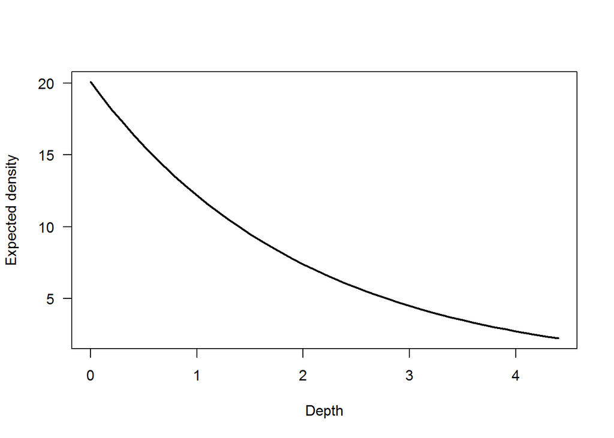

The effect of depth on abundace within an IRC is negative, indicating Pallid Sturgeon abundances are higher at lower depths. With the IRC this might look like the figure below where the expected density is $Abundance \sim Poisson(exp(\beta_{0} + \beta_{1} \cdot depth))$, where $\beta_{0} =$ 3 and $\beta_{1} =$ -0.5. The actual abundance for each site given the depth is illustrated below.

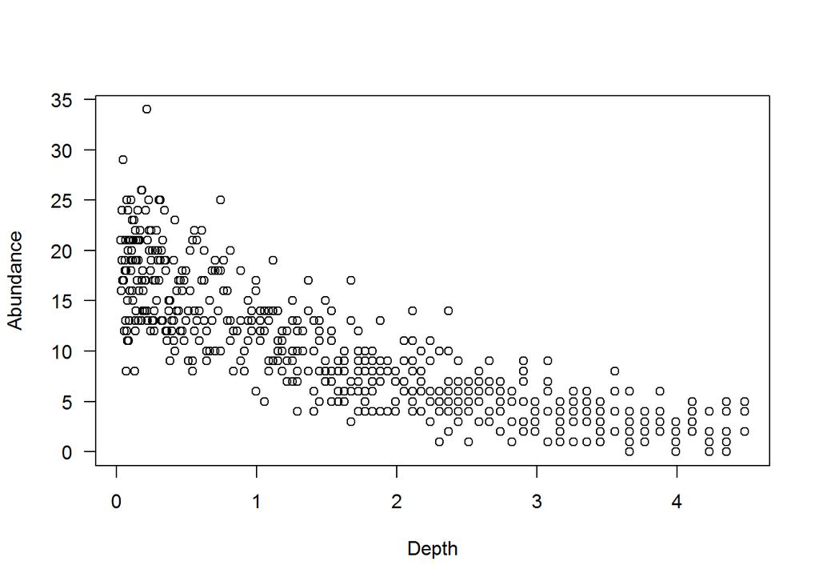

Similarly, capture probability can be related to depth or some other environmental covariate. Suppose that capture probability was a function of depth, this might be the case when using a seine and it might be very difficult to fish the deep areas, just a hypothetical example here. This relationship might look like the figure below where the capture probability is $logit(p) = \beta_{0} + \beta+{1} \cdot depth$, where $\beta_{0} =$ 1 and $\beta_{1} =$ -0.5.

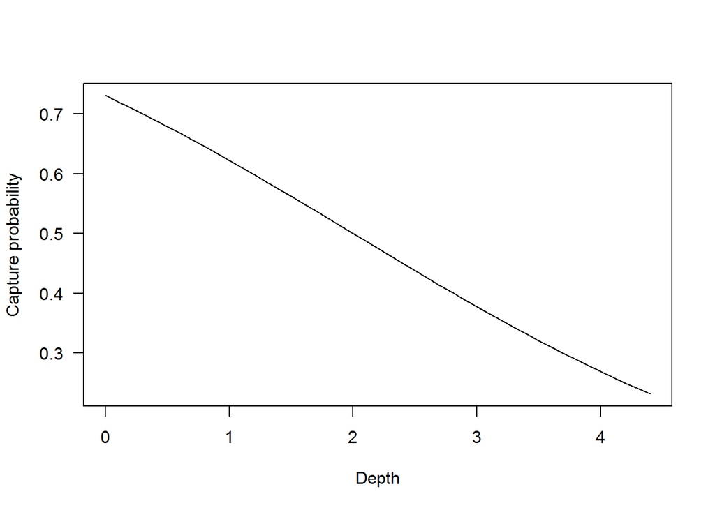

Using the relationship of $p$ and depth and the abundance at each site the capture histories can be generated accounting for site-specific depth and capture probability.

```r
# GENERATE CAPTURE HISTORIES
nocc<-5
p<- plogis(p_b0+p_b1*sampleSites$depth)
cap_dat<- matrix(0,nsamples,nocc)
for(i in 1:nsamples)
    {
    cap_dat[i,]<- rbinom(nocc,sampleSites$abundance[i],p[i])
    }
```

The simulated catch at each of the 40 sites for 5 occasions is shown below.

| siteId | occasion.1 | occasion.2 | occasion.3 | occasion.4 | occasion.5 |
| --- | --- | --- | --- | --- | --- |
| 1 | 0 | 0 | 0 | 3 | 1 |
| 2 | 2 | 1 | 1 | 1 | 4 |
| 3 | 14 | 16 | 14 | 14 | 10 |
| 4 | 3 | 1 | 3 | 2 | 2 |
| 5 | 5 | 4 | 4 | 3 | 1 |
| 6 | 3 | 5 | 3 | 7 | 4 |
| 7 | 6 | 8 | 4 | 9 | 8 |
| 8 | 4 | 7 | 7 | 6 | 7 |
| 9 | 7 | 5 | 7 | 8 | 6 |
| 10 | 3 | 2 | 3 | 4 | 2 |
| 11 | 2 | 3 | 4 | 5 | 2 |
| 12 | 4 | 5 | 4 | 6 | 4 |
| 13 | 4 | 1 | 5 | 4 | 5 |
| 14 | 6 | 7 | 7 | 6 | 7 |
| 15 | 8 | 9 | 11 | 7 | 10 |
| 16 | 12 | 9 | 9 | 10 | 11 |
| 17 | 15 | 14 | 13 | 11 | 11 |
| 18 | 10 | 9 | 9 | 9 | 9 |
| 19 | 15 | 19 | 18 | 19 | 18 |
| 20 | 11 | 8 | 12 | 12 | 12 |
| 21 | 6 | 6 | 7 | 7 | 2 |
| 22 | 1 | 3 | 1 | 1 | 2 |
| 23 | 10 | 10 | 6 | 8 | 12 |
| 24 | 16 | 12 | 12 | 13 | 17 |
| 25 | 7 | 7 | 7 | 7 | 8 |
| 26 | 1 | 1 | 1 | 1 | 1 |
| 27 | 3 | 4 | 4 | 4 | 4 |
| 28 | 3 | 1 | 3 | 1 | 2 |
| 29 | 5 | 6 | 4 | 5 | 4 |
| 30 | 11 | 10 | 8 | 7 | 5 |
| 31 | 0 | 2 | 0 | 0 | 1 |
| 32 | 10 | 9 | 11 | 10 | 10 |
| 33 | 2 | 1 | 2 | 1 | 4 |
| 34 | 3 | 7 | 7 | 10 | 8 |
| 35 | 3 | 6 | 7 | 4 | 6 |
| 36 | 6 | 6 | 7 | 7 | 7 |
| 37 | 5 | 7 | 7 | 9 | 5 |
| 38 | 6 | 5 | 5 | 5 | 4 |
| 39 | 4 | 0 | 2 | 2 | 2 |
| 40 | 0 | 0 | 0 | 0 | 1 |

The model is fit as before, but with 4 estimates produce 2 intercepts and 2 betas for the the relationship of depth on $\lambda$ and $p$.

```r
# PREPARE DATA
irc_data <- unmarkedFramePCount(y = cap_dat,siteCovs=data.frame(depth=sampleSites$depth))
# FIT THE MODEL WITH DEPTH AS A COVARIATE FOR LAMBDA AND P
fit <- pcount(~depth +1 ~depth+1, irc_data, K=150)
fit
```

```
##
## Call:
## pcount(formula = ~depth + 1 ~ depth + 1, data = irc_data, K = 150)
##
## Abundance:
##             Estimate    SE     z   P(>|z|)
## (Intercept)    2.714 0.102 26.73 2.00e-157
## depth         -0.317 0.104 -3.05  2.29e-03
##
## Detection:
##             Estimate    SE     z     P(>|z|)
## (Intercept)    1.183 0.225  5.26 0.000000143
## depth         -0.668 0.163 -4.09 0.000042300
##
## AIC: 776.1271
```

After fitting the *N*-mixture model the estimate of $\beta_{0}$ and $\beta_{1}$ a was 2.71 and -0.32, recall that the value used to generate the data was 3 and -0.5 for the relationship of abundance with depth. The estimate of $\beta_{0}$ and $\beta_{1}$ for the function relating capture probability to depth was 1.18 and -0.67, recall the that value used was 1 and -0.5.

Ignoring uncertainties for the moment, we can estimate the total abundance given depth at each location in the IRC as $N = \sum_{i=1}^{I} exp(2.71 \cdot -0.32 \cdot depth_{i})$, where $i$ indexes each grid in the IRC.

The image below illustrates the true abundances for a simulated IRC and the estimated abundances.

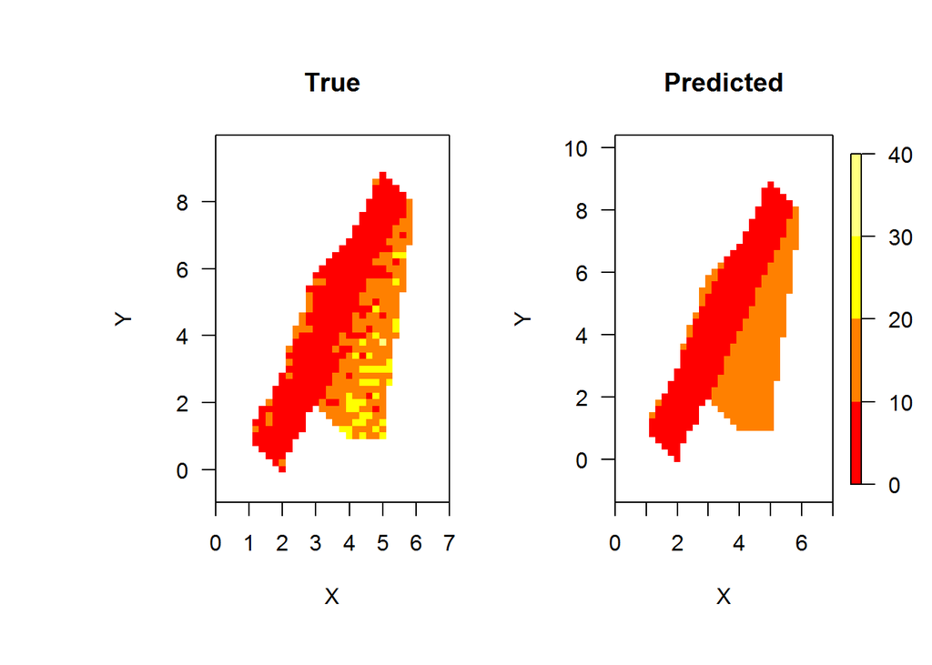

Using the predictions the estimate of abundance in the IRC is 4949 and the true abundance was 5236. There are design aspects where fine tuning can occur, such as modifying the number of replicates to take or how many sites to sample and where to put them.

## Caveats and considerations

- The approach provides estimates of abundance and density which can be comparabile among years if different gears are used
- How this approach is performs with **real world** data where things are messy has not be rigorously evaluated, but could be evauated using mesocosms, flumes, ponds to give it a try
- The approach assumes demographic closure among occasions, i.e., fish are not being recruited or lost from the population
- At least as simulated here it assumes fish stay put, but I suspect as along as mixing is random the consequences are minimal